# Laboratori sessió 4 - Introducció a resposta binaria

Lidia Montero, Josep Anton Sanchez & Jordi Cortés

# Votants americans

## Dades

- Eleccions
  - *close*: eleccions disputades
  - *onesided*: eleccions amb un clar guanyador
- Voten: *No, Yes*

Carregar les dades i veure els objectes en memoria.

```r
# install.packages("evd")
library(evd)                   # cloglog --> qgumbel
load("AmericanVoter.RData")
ls()
```

```
## [1] "campbell"     "df"           "last.warning" "tt"
```

Tres maneres de mostrar les dades.

```r
# TAULA DE CONTNGÈNCIA + les sumes marginals(m) + estimació de quants voten en cada categoria de X
campbell    # data.frame --> with row marginals and row probabilities
```

```
##   eleccions voten novoten   m   p.voten
## 1     close   699     188 887 0.7880496
## 2  onesided   276     112 388 0.7113402
```

```r
# TAULA DE FREQÜÈNCIES
df          # data.frame --> for models with aggregated data
```

```
##    FResult  FVotar   y
## 1    close   Voten 699
## 2 onesided   Voten 276
## 3    close NoVoten 188
## 4 onesided NoVoten 112
```

```r
#TAULA DE CONTINGÈNCIA
tt          # table --> Obtained as tt <- xtabs(df$y~df$FResult+df$FVotar)
```

```
##           df$FVotar
## df$FResult Voten NoVoten
##   onesided   276     112
##   close      699     188
```

```r
sum(tt) # Total d'enquestats (nº observacions)
```

```
## [1] 1275
```

## Independencia amb taules de contingencia.

Tenim: Y (resposta binària) i una sola var explicativa X (factor).

Y: FVotar (si vota o no vota)

Volem saber quins factors fan que la gent NO vagi a votar.

X: Fresult (oneside, un clar guanyador, close,eleccions empatades). És també una variable binària.

#### Calcular el nombre esperat de votants/No votants sota la hipotesi de independencia $(H_0)$:

Test de independència = test d’hmogeneitat Ho: P(V_i U(al revés) R_j) = P(V_i) H1: no igual

Estimació de P(V_i)= marginal(n_·1)/N

S’ha de considerar que la probabilitat de votar és la mateixa si les eleccions estan disputades com si no:

$H_0: \pi_{V|C}=\pi_{V|O}$

Calcularem les freqüències esperades sota independencia:

```r
pVotar <- sum(campbell$voten)/sum(campbell$m)
campbell$p0Voten   <- campbell$m * pVotar # Valors teòrics dels que haurien d'haver votat sota Ho (sota independència)
campbell$p0noVoten <- campbell$m * (1-pVotar) # Valors teòrics dels que no haurien d'haver votat sota la Ho d'independència

# Taula d'efectius esperats sobre independència
campbell
```

```
##   eleccions voten novoten   m   p.voten  p0Voten p0noVoten
## 1     close   699     188 887 0.7880496 678.2941 208.70588
## 2  onesided   276     112 388 0.7113402 296.7059  91.29412
```

#### Bondad d’ajust

Per respondre a la pregunta a si el model que estem plantejant és adequat per explicar el comportament del que estem observant a les dades.

Emprarem 2 estadístics per valorar la bondad d’ajust de considerar independència:

- L’estadístic de Pearson ($\chi^2_P$) generalitzat
- La deviança ($D$)

Primer, calcularem l’estadístic de Pearson:

$\chi^2_P=\sum_{i,j}{\frac{(O_{ij}-E_{ij})^2}{E_{ij}}}$

```r
X2P <- with(campbell,sum((p0Voten  -voten)^2  /p0Voten +
                         (p0noVoten-novoten)^2/p0noVoten))
pvalor <- 1-pchisq(X2P,1)
X2P;pvalor
```

```
## [1] 8.827482
```

```
## [1] 0.002967276
```

Regió crítica: qchisq(0.95,1)=3.84. Si la suma X2p sobrepassa aquest valor, diem que tenim evidències per rebutjar Ho. També es vàlid.

Ara, calcularem l’estadístic de la deviança:

$D=2 \cdot \sum{\big[y_i \cdot log(\frac{y_i}{m_i\hat{\pi}_i}) + (m_i - y_i) \cdot log(\frac{m_i - y_i}{m_i - m_i\hat{\pi}_i}) \big]}$

```r
Dev0 <- 2*sum(with(campbell,log(voten/p0Voten)     * voten +
                            log(novoten/p0noVoten) * novoten))
pvalue <- 1 - pchisq(Dev0,1)
Dev0;pvalue
```

```
## [1] 8.607962
```

```
## [1] 0.003346966
```

Resultats equivalents als de la R^2.

Amb la funció *chisq.test* es pot fer el test d’independencia per una taula IxJ

Amb correcció de Yates:

Té en compte que si alguna de les caselles de la taula de contingència té un valor esperat menor a 5, sha de fer una correcció de continuitat.

```r
chisq.test(tt)
```

```
##
##  Pearson's Chi-squared test with Yates' continuity correction
##
## data:  tt
## X-squared = 8.4063, df = 1, p-value = 0.003739
```

Sense correcció de Yates:

Veiem que coincideix amb l’obtingut en primer lloc.

```r
chi.test <- chisq.test(tt,correct = FALSE)
chi.test
```

```
##
##  Pearson's Chi-squared test
##
## data:  tt
## X-squared = 8.8275, df = 1, p-value = 0.002967
```

Amb la funció *chisq.test* podem obtenir:

- Els efectius esperats:

```r
chi.test$expected
```

```
##           df$FVotar
## df$FResult    Voten   NoVoten
##   onesided 296.7059  91.29412
##   close    678.2941 208.70588
```

- Els residus i l’estadístic de Pearson:

```r
chi.test$residuals
```

```
##           df$FVotar
## df$FResult      Voten    NoVoten
##   onesided -1.2020725  2.1670670
##   close     0.7950322 -1.4332647
```

```r
sum(chi.test$residuals^2)
```

```
## [1] 8.827482
```

```r
chi.test$statistic
```

```
## X-squared
##  8.827482
```

- El p-valor:

```r
chi.test$p.value
```

```
## [1] 0.002967276
```

## Mesures

- Per cada categoria de tipus d’elecció:
  - Probabilitat de votar. Són els que voten en una categoria entre el total de la categoria.
  - Odds de votar. Són els que voten en una categoria entre els que no voten.
- Relació entre categories:
  - Odds-ratio. És el rati d’odds.

```r
campbell$p1pos <- with(campbell,voten/m)
campbell$p1neg <- with(campbell,novoten/m)
campbell$odd1  <- with(campbell,voten/novoten)
oddsratio <- with(campbell,odd1[1]/odd1[2])            # Categoria de referencia is onesided (2nd row)
campbell;oddsratio
```

```
##   eleccions voten novoten   m   p.voten  p0Voten p0noVoten     p1pos
## 1     close   699     188 887 0.7880496 678.2941 208.70588 0.7880496
## 2  onesided   276     112 388 0.7113402 296.7059  91.29412 0.7113402
##       p1neg     odd1
## 1 0.2119504 3.718085
## 2 0.2886598 2.464286
```

```
## [1] 1.508788
```

## Funcions Link

#### Logit link: Model sota $H_0$

Aquesta funció link representa el logaritme del odd i és la funció link que proporciona resultats més interpretables ja que es poden obtenir els odds i els odds ratis a traves de desfer les transformacions.

Sota $H_0$:

$H_0: \pi_{V|C}=\pi_{V|O}$

```r
(beta0 <- with(campbell,log(pVotar/(1-pVotar))))
```

```
## [1] 1.178655
```

```r
ml0 <- glm(cbind(voten,novoten) ~ 1,family=binomial(link="logit"), data=campbell)
summary(ml0)
```

```
##
## Call:
## glm(formula = cbind(voten, novoten) ~ 1, family = binomial(link = "logit"),
##     data = campbell)
##
## Deviance Residuals:
##      1       2
##  1.659  -2.420
##
## Coefficients:
##             Estimate Std. Error z value Pr(>|z|)
## (Intercept)  1.17865    0.06602   17.85   <2e-16 ***
## ---
## Signif. codes:  0 '***' 0.001 '**' 0.01 '*' 0.05 '.' 0.1 ' ' 1
##
## (Dispersion parameter for binomial family taken to be 1)
##
##     Null deviance: 8.608  on 1  degrees of freedom
## Residual deviance: 8.608  on 1  degrees of freedom
## AIC: 23.662
##
## Number of Fisher Scoring iterations: 4
```

#### Logit link: Model sota $H_1$

Sota $H_1$:

$H_1: \pi_{V|C} \ne \pi_{V|O}$

```r
(beta1 <- with(campbell,log(p1pos/(1-p1pos)))) # Reference level is onesided - 2nd row !!!
```

```
## [1] 1.313209 0.901902
```

```r
beta1[2]                                       # Constant estimate related to reference level eleccions=='onesided'
```

```
## [1] 0.901902
```

```r
beta1[1]-beta1[2]                               # Additive value over the reference for eleccions=='closed'
```

```
## [1] 0.4113068
```

```r
ml1 <- glm(cbind(voten,novoten)~eleccions,family=binomial(link="logit"),data=campbell)
summary(ml1)
```

```
##
## Call:
## glm(formula = cbind(voten, novoten) ~ eleccions, family = binomial(link = "logit"),
##     data = campbell)
##
## Deviance Residuals:
## [1]  0  0
##
## Coefficients:
##                Estimate Std. Error z value Pr(>|z|)
## (Intercept)      0.9019     0.1120   8.050 8.27e-16 ***
## eleccionsclose   0.4113     0.1389   2.961  0.00307 **
## ---
## Signif. codes:  0 '***' 0.001 '**' 0.01 '*' 0.05 '.' 0.1 ' ' 1
##
## (Dispersion parameter for binomial family taken to be 1)
##
##     Null deviance:  8.608e+00  on 1  degrees of freedom
## Residual deviance: -8.793e-14  on 0  degrees of freedom
## AIC: 17.054
##
## Number of Fisher Scoring iterations: 2
```

#### Probit link: Model sota $H_0$

Aquesta funció link representa el quantil de la normal estandard de la probabilitat de votar.

Sota $H_0$:

$H_0: \pi_{V|C}=\pi_{V|O}$

```r
beta0 <- qnorm(pVotar);beta0
```

```
## [1] 0.7215223
```

```r
mn0  <- glm(cbind(voten,novoten)~1, family=binomial(link="probit"), data=campbell)
summary(mn0)
```

```
##
## Call:
## glm(formula = cbind(voten, novoten) ~ 1, family = binomial(link = "probit"),
##     data = campbell)
##
## Deviance Residuals:
##      1       2
##  1.659  -2.420
##
## Coefficients:
##             Estimate Std. Error z value Pr(>|z|)
## (Intercept)  0.72152    0.03863   18.68   <2e-16 ***
## ---
## Signif. codes:  0 '***' 0.001 '**' 0.01 '*' 0.05 '.' 0.1 ' ' 1
##
## (Dispersion parameter for binomial family taken to be 1)
##
##     Null deviance: 8.608  on 1  degrees of freedom
## Residual deviance: 8.608  on 1  degrees of freedom
## AIC: 23.662
##
## Number of Fisher Scoring iterations: 3
```

#### Probit link: Model sota $H_1$

Sota $H_1$:

$H_1: \pi_{V|C} \ne \pi_{V|O}$

```r
beta1 <- qnorm(campbell$p1pos);beta1 # Reference level is onesided - 2nd row !!!
```

```
## [1] 0.7996721 0.5573042
```

```r
beta1[2]                            # Constant estimate related to reference level eleccions=='onesided'
```

```
## [1] 0.5573042
```

```r
beta1[1]-beta1[2]                    # Additive value over the reference for eleccions=='closed'
```

```
## [1] 0.2423679
```

```r
mn1 <- glm(cbind(voten,novoten)~eleccions,family=binomial(link="probit"),data=campbell)
summary(mn1)
```

```
##
## Call:
## glm(formula = cbind(voten, novoten) ~ eleccions, family = binomial(link = "probit"),
##     data = campbell)
##
## Deviance Residuals:
## [1]  0  0
##
## Coefficients:
##                Estimate Std. Error z value Pr(>|z|)
## (Intercept)     0.55730    0.06735   8.275  < 2e-16 ***
## eleccionsclose  0.24237    0.08233   2.944  0.00324 **
## ---
## Signif. codes:  0 '***' 0.001 '**' 0.01 '*' 0.05 '.' 0.1 ' ' 1
##
## (Dispersion parameter for binomial family taken to be 1)
##
##     Null deviance: 8.608e+00  on 1  degrees of freedom
## Residual deviance: 1.350e-13  on 0  degrees of freedom
## AIC: 17.054
##
## Number of Fisher Scoring iterations: 2
```

#### Complementary-log-log link: Model sota $H_0$

Aquesta funció link es construeix a través del quantil de la distribució gumbel.

```r
beta0 <- 0 - qgumbel(1-pVotar);beta0
```

```
## [1] 0.3694365
```

```r
mg0  <- glm(cbind(voten,novoten)~1,family=binomial(link="cloglog"),data=campbell)
summary(mg0)
```

```
##
## Call:
## glm(formula = cbind(voten, novoten) ~ 1, family = binomial(link = "cloglog"),
##     data = campbell)
##
## Deviance Residuals:
##      1       2
##  1.659  -2.420
##
## Coefficients:
##             Estimate Std. Error z value Pr(>|z|)
## (Intercept)  0.36944    0.03489   10.59   <2e-16 ***
## ---
## Signif. codes:  0 '***' 0.001 '**' 0.01 '*' 0.05 '.' 0.1 ' ' 1
##
## (Dispersion parameter for binomial family taken to be 1)
##
##     Null deviance: 8.608  on 1  degrees of freedom
## Residual deviance: 8.608  on 1  degrees of freedom
## AIC: 23.662
##
## Number of Fisher Scoring iterations: 3
```

#### Complementary-log-log: Model sota $H_1$

Sota $H_1$:

$H_1: \pi_{V|C} \ne \pi_{V|O}$

```r
beta1 <- 0-qgumbel(1-campbell$p1pos);beta1 # Reference level is onesided - 2nd row !!!
```

```
## [1] 0.4391597 0.2171307
```

```r
beta1[2]  # Constant estimate related to reference level eleccions=='onesided'
```

```
## [1] 0.2171307
```

```r
beta1[1]-beta1[2] # Additive value over the reference for eleccions=='closed'
```

```
## [1] 0.222029
```

```r
mg1 <- glm(cbind(voten,novoten)~eleccions,family=binomial(link="cloglog"),data=campbell)
summary(mg1)
```

```
##
## Call:
## glm(formula = cbind(voten, novoten) ~ eleccions, family = binomial(link = "cloglog"),
##     data = campbell)
##
## Deviance Residuals:
## [1]  0  0
##
## Coefficients:
##                Estimate Std. Error z value Pr(>|z|)
## (Intercept)     0.21713    0.06414   3.385 0.000711 ***
## eleccionsclose  0.22203    0.07652   2.902 0.003714 **
## ---
## Signif. codes:  0 '***' 0.001 '**' 0.01 '*' 0.05 '.' 0.1 ' ' 1
##
## (Dispersion parameter for binomial family taken to be 1)
##
##     Null deviance: 8.6080e+00  on 1  degrees of freedom
## Residual deviance: 3.5083e-14  on 0  degrees of freedom
## AIC: 17.054
##
## Number of Fisher Scoring iterations: 2
```

#### Diferents formes de les funcions link

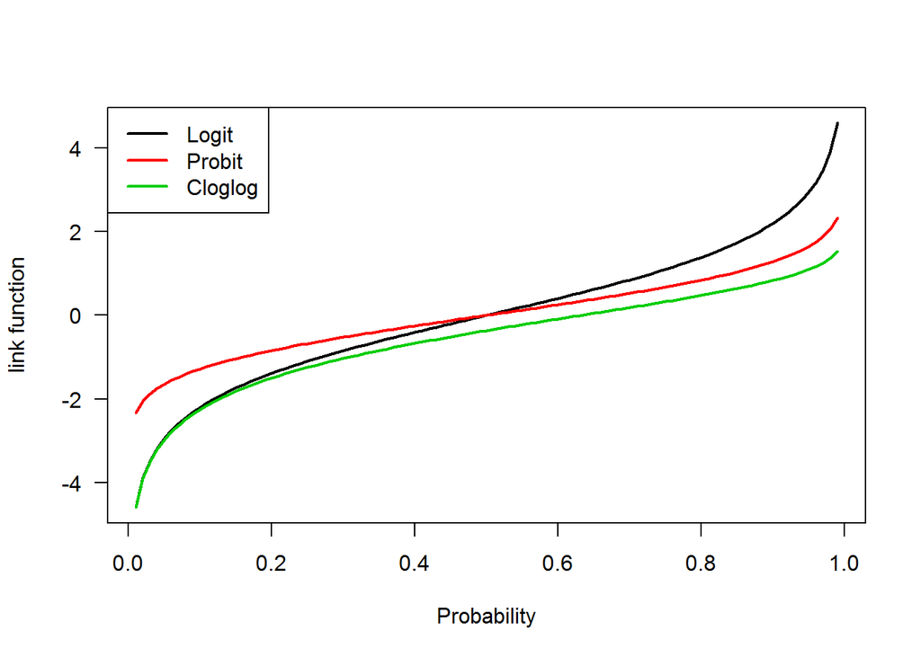

```r
ps <- seq(0.01,0.99,0.01)
flogit <- log(ps/(1-ps))
fprobit <- qnorm(ps)
fcloglog <- log(-log(1-ps))

par(las=1)
plot(ps,flogit,type='l',lwd=2,col=1,xlab='Probability',ylab='link function')
lines(ps,fprobit,type='l',lwd=2,col=2)
lines(ps,fcloglog,type='l',lwd=2,col=3)
legend('topleft',c('Logit','Probit','Cloglog'),lwd=2,col=1:3)
```

Aquí es veu la diferent distribució de les 3 funcions. Depenent de com augmenti/decreixi la probabilitat de la resposta en funció del valor de la variable predictora, escollirem una o altra.